# Machine Learning Method Comparison

# Introduction

The goal of this final project is to predict the interest rate of a loan, based off various payment and income information. This dataset includes all loan data for all loans issued by Lending Club from 2007 to 2019, comprising over 2 million observations. Due to computing constraints, the analysis to the first 10,000 observations. With this data, I will explore the regression methods we learned this quarter, as well as their sensitivity to the different test-train data splits.

Imports

```r
library(leaps)
library(glmnet)
library(dplyr)
library(gam)
library(splines)
library (gbm)
library(ggplot2)
library(nnet)
library(boot)
library(MASS)
library(tree)
library(randomForest)
library(caret)
```

# Data Cleaning

Our dataset has many variables that caused instances of high linear dependance or other errors when designing our models, so we only kept variables that we though would be pertinent to our study.

```r
loans = read.csv("loan.csv", nrows = 10000)
```

Remove columns from dataset that have missing values in at least half the rows of the dataset. Also remove columns from data set where the values of each row are all the same.

```r
loans = loans[, colSums(is.na(loans)) < nrow(loans)/2]
loans = Filter(function(x) length(unique(x))>1, loans)
```

Keep columns that we believe to be pertinent to interest rate and not linearly dependent. Also removed rows with N/A.

```r
loans=loans[ , which(names(loans) %in% c("funded_amnt", "term", "int_rate", "emp_length", "home_ownership", "annual_inc", "verification_status",  "purpose", "delinq_2yrs", "earliest_cr_line", "open_acc", "pub_rec", "revol_bal", "initial_list_status", "acc_open_past_24mths", "avg_cur_bal", "num_sats", "pub_rec_bankruptcies"))]

# turn date format into an int
dates = paste('01', loans$earliest_cr_line)
loans$earliest_cr_line = as.Date(dates, format = "%d %b-%Y")
loans$earliest_cr_line = as.integer(loans$earliest_cr_line)

# emp_length had some N/A stored as a string
loans = loans[!(loans$emp_length=="n/a"),]
loans$emp_length = factor(loans$emp_length)
loans = na.omit(loans)

head(loans)
```

```
##   funded_amnt       term int_rate emp_length home_ownership annual_inc
## 1        2500  36 months    13.56  10+ years           RENT      55000
## 2       30000  60 months    18.94  10+ years       MORTGAGE      90000
## 3        5000  36 months    17.97    6 years       MORTGAGE      59280
## 4        4000  36 months    18.94  10+ years       MORTGAGE      92000
## 5       30000  60 months    16.14  10+ years       MORTGAGE      57250
## 6        5550  36 months    15.02  10+ years       MORTGAGE     152500
##   verification_status            purpose delinq_2yrs earliest_cr_line open_acc
## 1        Not Verified debt_consolidation           0            11413        9
## 2     Source Verified debt_consolidation           0             6360       13
## 3     Source Verified debt_consolidation           0            15065        8
## 4     Source Verified debt_consolidation           0            13180       10
## 5        Not Verified debt_consolidation           0            11292       12
## 6        Not Verified        credit_card           0            11931       18
##   pub_rec revol_bal initial_list_status acc_open_past_24mths avg_cur_bal
## 1       1      4341                   w                    9        1878
## 2       1     12315                   w                   10       24763
## 3       0      4599                   w                    4       18383
## 4       0      5468                   w                    5       30505
## 5       0       829                   w                    9        9667
## 6       0     53854                   w                    8       40338
##   num_sats pub_rec_bankruptcies
## 1        9                    1
## 2       13                    1
## 3        8                    0
## 4       10                    0
## 5       12                    0
## 6       18                    0
```

# Data Exploration

### term vs. int_rate

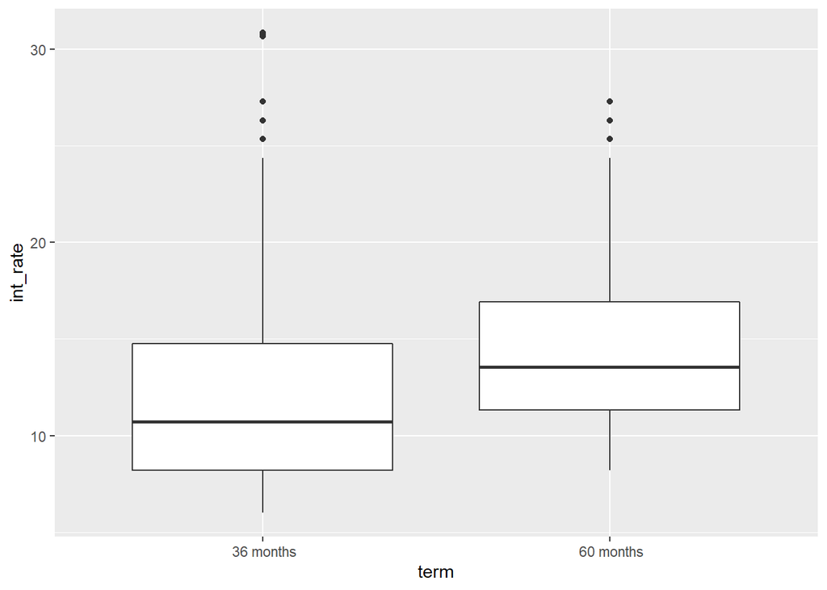

```r
ggplot(data=loans, aes(x=term, y=int_rate)) +
  geom_boxplot()
```

There seems to be a difference in average int_rate for the different term lengths. 60 month loans have an average higher interest rate.

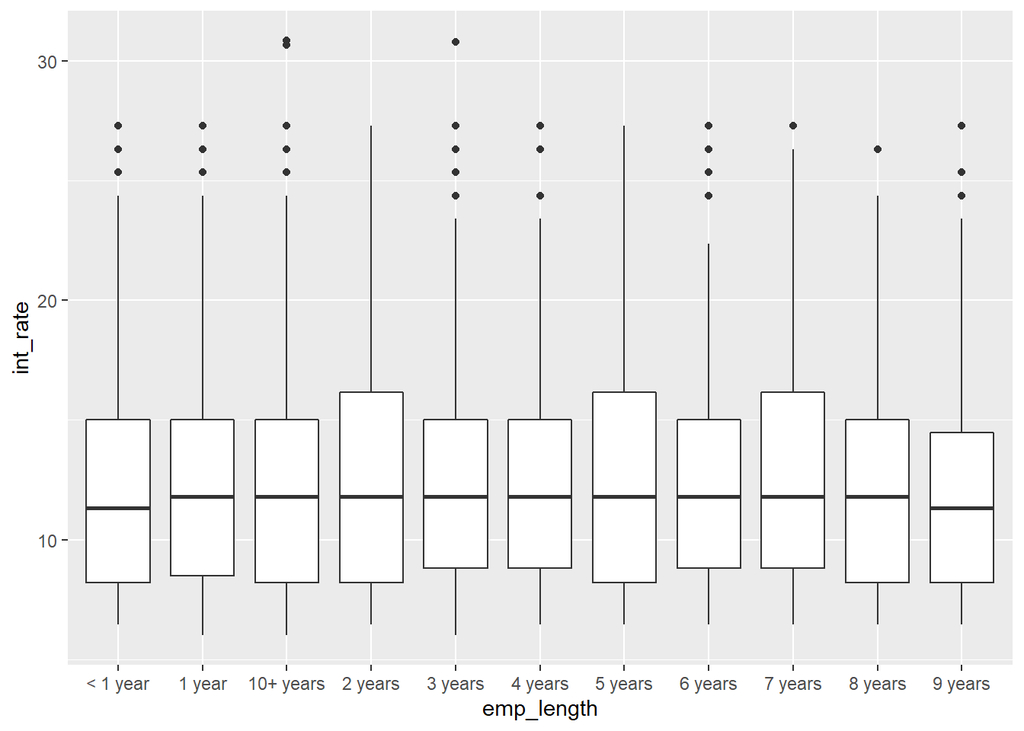

```r
ggplot(data=loans, aes(x=emp_length, y=int_rate)) +
  geom_boxplot()
```

There does not some to be any relationship between employment length and loan interest rate.

### home_ownership vs. int_rate

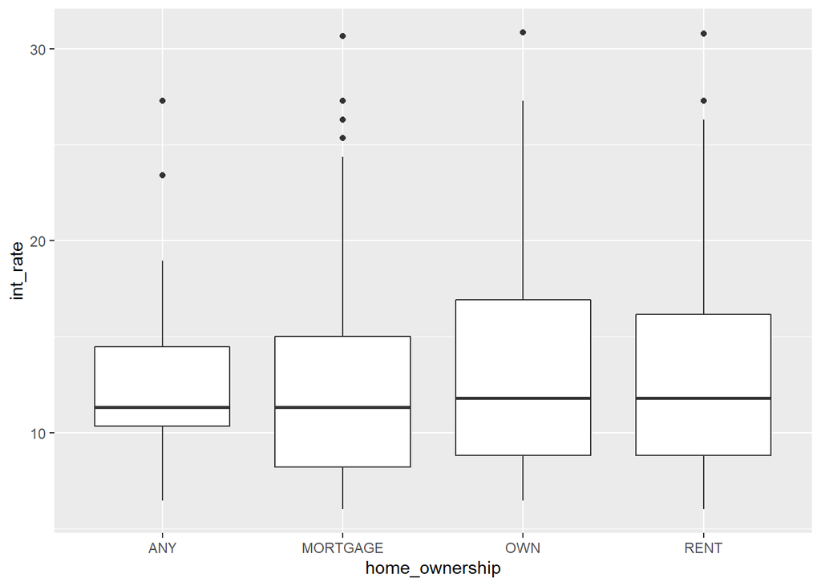

```r
ggplot(data=loans, aes(x=home_ownership, y=int_rate)) +
  geom_boxplot()
```

### annual_inc vs. int_rate

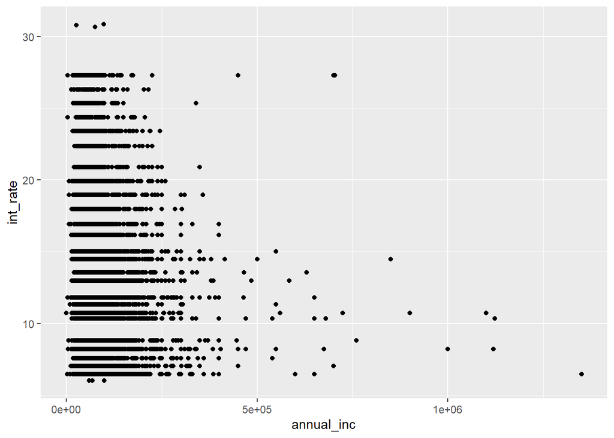

```r
ggplot(data=loans, aes(x=annual_inc, y=int_rate)) +
  geom_point()
```

From this graph, there seems to be a slight trend where higher income people get lower interest rates.

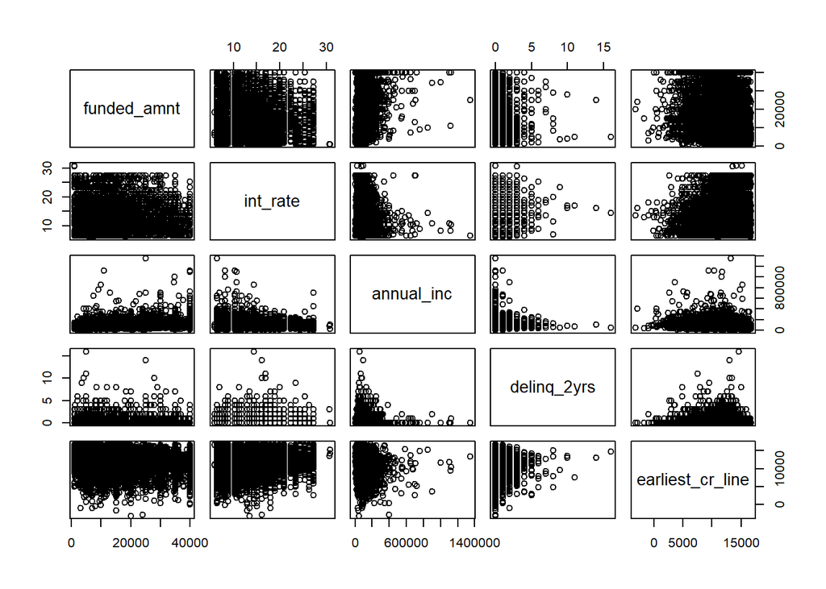

```r
plot(loans[,c(1,3,6, 9,10)])
```

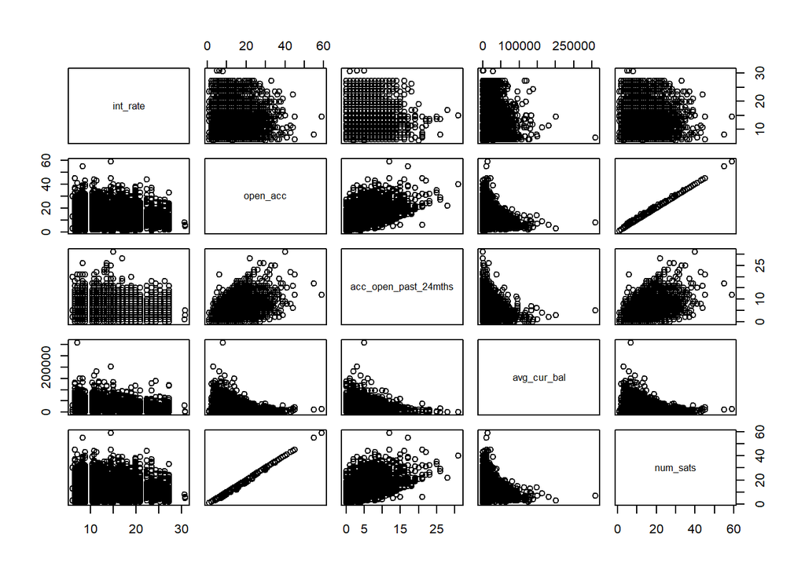

```r
plot(loans[,c(3,11, 15:17)])
```

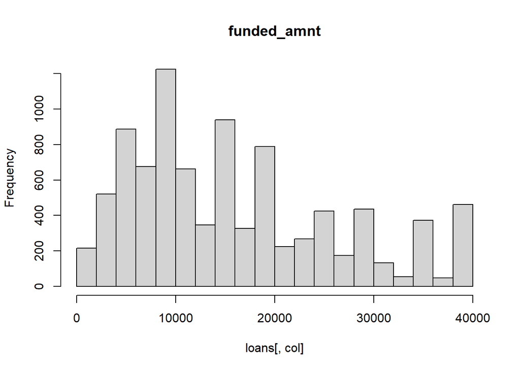

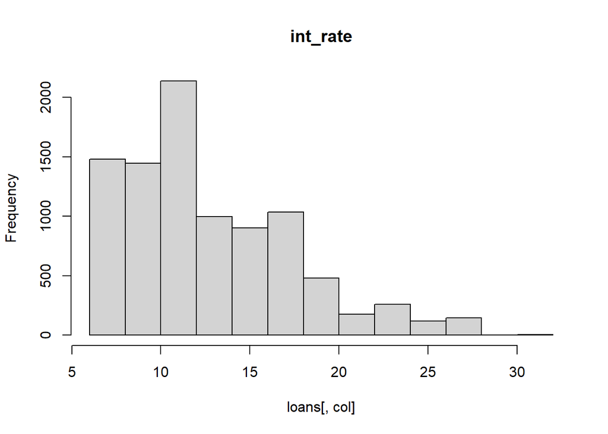

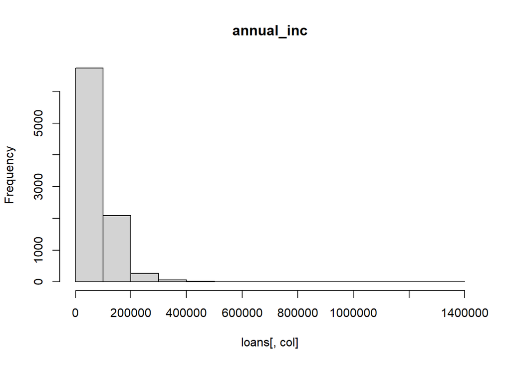

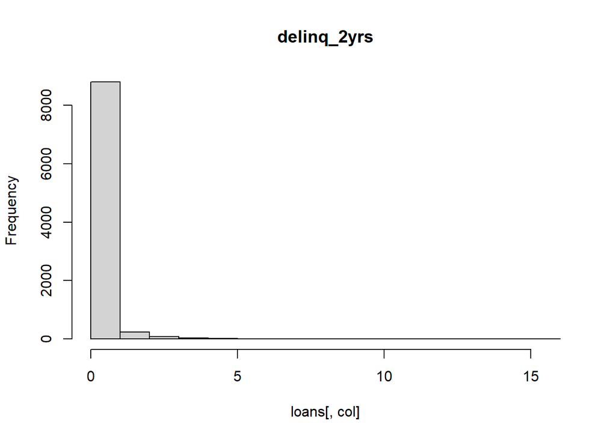

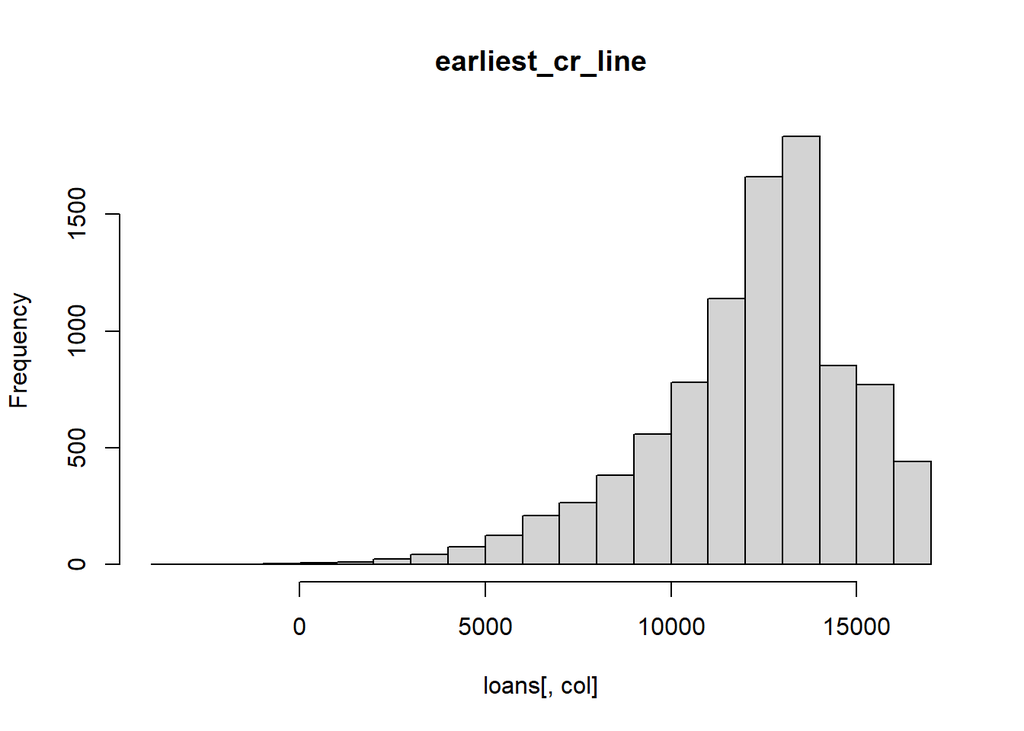

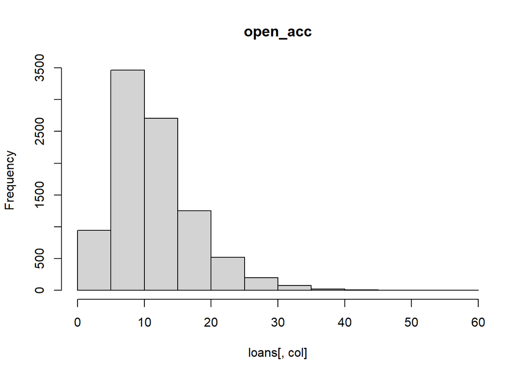

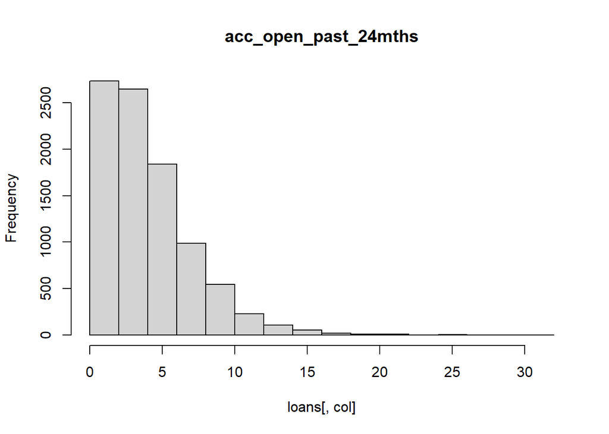

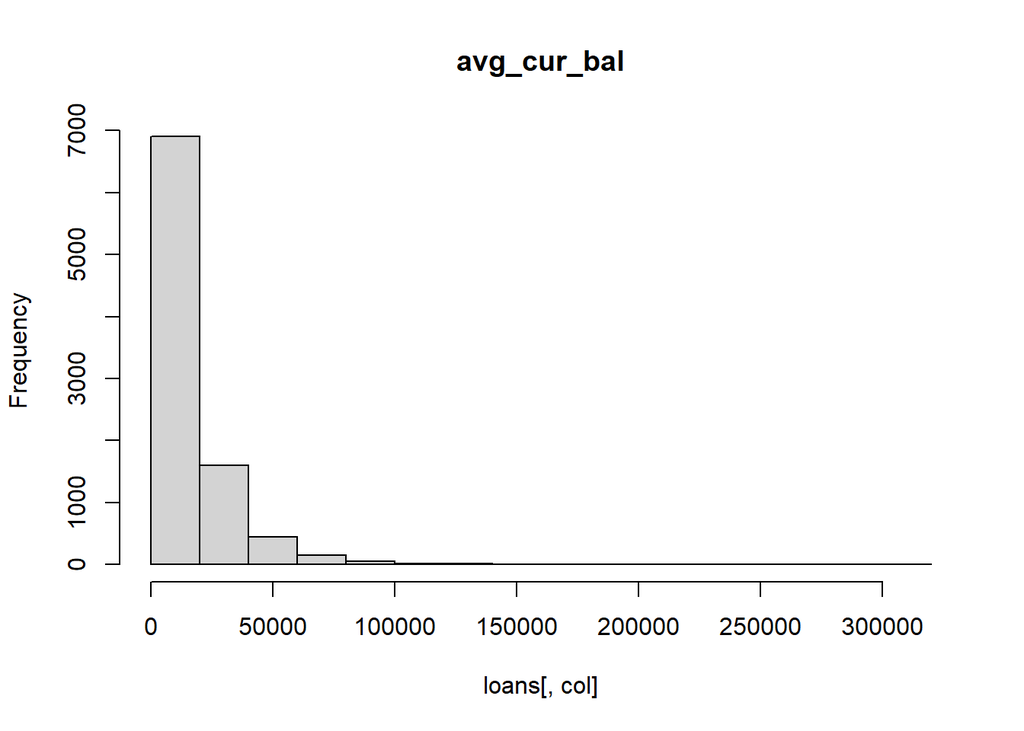

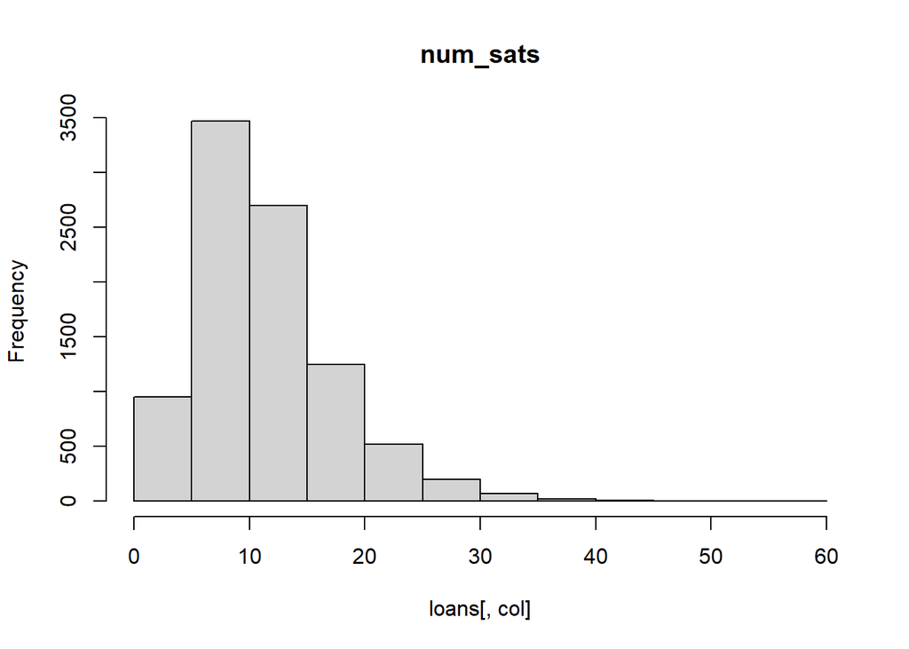

```r
for (col in c(1,3,6, 9:11, 15:17)){
  hist(loans[,col], main = names(loans[col]))
}
```

```r
for(col in c(2,4,5,7,8,12,14,18)){
  print(names(loans[col]))
  print(table(loans[,col]))
}
```

```
## [1] "term"
##
##  36 months  60 months
##       6283       2900
## [1] "emp_length"
##
##  < 1 year    1 year 10+ years   2 years   3 years   4 years   5 years   6 years
##      1268       727      2925       922       801       564       628       436
##   7 years   8 years   9 years
##       370       313       229
## [1] "home_ownership"
##
##      ANY MORTGAGE      OWN     RENT
##       17     4613      876     3677
## [1] "verification_status"
##
##    Not Verified Source Verified        Verified
##            4490            3581            1112
## [1] "purpose"
##
##                car        credit_card debt_consolidation   home_improvement
##                 91               2569               4940                497
##              house     major_purchase            medical             moving
##                 76                158                 95                 45
##              other   renewable_energy     small_business           vacation
##                533                  7                 89                 83
## [1] "pub_rec"
##
##    0    1    2    3
## 8168 1008    5    2
## [1] "initial_list_status"
##
##    f    w
## 1082 8101
## [1] "pub_rec_bankruptcies"
##
##    0    1    2    3
## 8168 1008    5    2
```

From the matrix of plots we can see that int_rate does seem to have a non-linear relationship with any variable other that annual_inc.

# Variable Selection

For variable selection, we tested four different methods, Forwards stepwise, Backwards stepwise, Ridge regression, and LASSO. For Ridge regression and LASSO, we used cross validation in order to find the best value of $\lambda$.

```r
set.seed(2)
loans = na.omit(loans)
train = sample(nrow(loans), nrow(loans)/2)
loans_train=loans[train,]
loans_test=loans[-train,]
```

## Forward stepwise

```r
predict.regsubsets =function (object ,newdata ,id ,...){
form=as.formula (object$call [[2]])
mat=model.matrix (form ,newdata )
coefi =coef(object ,id=id)
xvars =names (coefi )
mat[,xvars ]%*% coefi
}

forwardm = regsubsets(int_rate~., data = loans_train, method = "forward", nvmax = ncol(loans)-1)
val.errors = rep(NA, ncol(loans)-1)
for (i in 1:(ncol(loans)-1)) {
    pred = predict.regsubsets(forwardm, loans_test, i)
    val.errors[i] = mean((loans_test$int_rate - pred)^2)
}
min(val.errors)
```

```
## [1] 19.46113
```

## Backward stepwise

```r
backwardm = regsubsets(int_rate~., data = loans_train, method = "backward", nvmax = ncol(loans)-1)
val.errors = rep(NA, ncol(loans)-1)
for (i in 1:(ncol(loans)-1)) {
    pred = predict.regsubsets(backwardm, loans_test, i)
    val.errors[i] = mean((loans_test$int_rate - pred)^2)
}

min(val.errors)
```

```
## [1] 19.53017
```

## Ridge Regression

```r
library(glmnet)

x = model.matrix(int_rate ~ ., loans)[,-1]
y = loans$int_rate

cv.out = cv.glmnet(x[train,], y[train], alpha = 0)
bestlam = cv.out$lambda.min
ridgem = glmnet(x[train,],y[train],alpha =0, lambda =bestlam)
ridge.pred = predict(ridgem, s = bestlam, newx = x[-train,])
mean((y[-train] - ridge.pred)^2)
```

```
## [1] 19.50978
```

## LASSO

```r
cv.out = cv.glmnet(x[train,], y[train], alpha = 1)
bestlam = cv.out$lambda.min
lassom = glmnet(x[train,],y[train],alpha =1, lambda =bestlam)
lasso.pred = predict(lassom, s = bestlam, newx = x[-train,])
mean((y[-train] - lasso.pred)^2)
```

```
## [1] 19.50922
```

Forward Stepwise ended up returning the lowest test error at about 19.46 followed by LASSO and Ridge Regression at 19.51 and the stepwise backwards at 19.53. All methods return very similar test errors, so using any method should probably be acceptable. For our own varaible reduction method, we are going to use the forwards subset selection because it returned the best test error.

```r
coef(forwardm, which.min(val.errors))
```

```
##                        (Intercept)                        funded_amnt
##                       1.241261e+01                      -5.632535e-05
##                     term 60 months             home_ownershipMORTGAGE
##                       3.076664e+00                      -9.873424e-01
##                         annual_inc verification_statusSource Verified
##                      -4.170979e-06                       1.096241e+00
##        verification_statusVerified                 purposecredit_card
##                       2.413346e+00                      -2.245862e+00
##          purposedebt_consolidation                       purposeother
##                      -8.025377e-01                       9.422172e-01
##                        delinq_2yrs                   earliest_cr_line
##                       8.013417e-01                       1.031085e-04
##                          revol_bal               initial_list_statusw
##                       7.989299e-06                      -6.703765e-01
##               acc_open_past_24mths                           num_sats
##                       2.411965e-01                      -6.320020e-02
```

Forward stepwise tells us the best model is the reduced model with the 12 variables funded_amnt, term, home_ownership, annual_inc, verification_status, purpose, delinq_2yrs, earliest_cr_line, revol_bal, initial_list_status, acc_open_past_24mths, and num_stats.

subset our data to include only variables that our variable selection method returned.

```r
loans = loans[,-c(4,11,12,16,18,19)]
#changing character data to factors
loans$home_ownership = as.factor(loans$home_ownership)
loans$term = as.factor(loans$term)
loans$verification_status = as.factor(loans$verification_status)
loans$purpose = as.factor(loans$purpose)
loans$initial_list_status = as.factor(loans$initial_list_status)
```

# Model exploration

```r
set.seed(2)
loans = na.omit(loans)
trainsm = sample(nrow(loans), 500)

#filtering out variables that are not in both test and train data
loans = filter(loans, home_ownership != 'ANY')
loans = filter(loans, !purpose %in% c('house', 'renewable_energy', 'moving'))


loans_trainsm=loans[trainsm,]
loans_testsm=loans[-trainsm,]
trainsm = sample(nrow(loans), 500)
loans_trainsm=loans[trainsm,]
loans_testsm=loans[-trainsm,]

trainmed=sample(nrow(loans), 1000)
loans_trainmed=loans[trainmed,]
loans_testmed=loans[-trainmed,]

trainlar = sample(nrow(loans), nrow(loans)/2)
loans_trainlar=loans[trainlar,]
loans_testlar=loans[-trainlar,]
```

## Multiple Regression

```r
mlrsm = glm(data = loans_trainsm, int_rate~.)
mlrsmte = mean((loans_testsm$int_rate - predict(mlrsm, loans_testsm))^2)
mlrsmte
```

```
## [1] 19.99028
```

```r
summary(mlrsm)
```

```
##
## Call:
## glm(formula = int_rate ~ ., data = loans_trainsm)
##
## Deviance Residuals:
##     Min       1Q   Median       3Q      Max
## -9.6792  -3.0589  -0.9127   2.2229  15.5963
##
## Coefficients:
##                                      Estimate Std. Error t value Pr(>|t|)
## (Intercept)                         6.477e+00  2.657e+00   2.438 0.015131 *
## funded_amnt                        -8.930e-05  2.637e-05  -3.387 0.000766 ***
## term 60 months                      4.215e+00  4.688e-01   8.989  < 2e-16 ***
## home_ownershipOWN                   2.486e+00  6.739e-01   3.689 0.000251 ***
## home_ownershipRENT                  1.158e+00  4.509e-01   2.568 0.010544 *
## annual_inc                         -7.284e-06  4.723e-06  -1.542 0.123718
## verification_statusSource Verified  1.196e+00  4.404e-01   2.716 0.006845 **
## verification_statusVerified         2.261e+00  6.620e-01   3.416 0.000690 ***
## purposecredit_card                  1.338e+00  2.243e+00   0.597 0.550970
## purposedebt_consolidation           3.262e+00  2.234e+00   1.460 0.144996
## purposehome_improvement             3.021e+00  2.380e+00   1.269 0.204977
## purposemajor_purchase               4.893e+00  2.683e+00   1.824 0.068824 .
## purposemedical                      1.210e+00  2.778e+00   0.435 0.663455
## purposeother                        5.475e+00  2.381e+00   2.300 0.021897 *
## purposesmall_business               3.397e+00  2.777e+00   1.223 0.221877
## purposevacation                     1.007e+01  2.985e+00   3.373 0.000805 ***
## delinq_2yrs                         7.453e-01  2.545e-01   2.929 0.003563 **
## earliest_cr_line                    1.745e-04  8.089e-05   2.157 0.031501 *
## revol_bal                           2.925e-05  1.119e-05   2.614 0.009240 **
## initial_list_statusw               -1.097e+00  6.231e-01  -1.761 0.078864 .
## acc_open_past_24mths                1.153e-01  7.725e-02   1.493 0.136084
## num_sats                            1.409e-02  4.360e-02   0.323 0.746752
## ---
## Signif. codes:  0 '***' 0.001 '**' 0.01 '*' 0.05 '.' 0.1 ' ' 1
##
## (Dispersion parameter for gaussian family taken to be 19.31345)
##
##     Null deviance: 12754.4  on 499  degrees of freedom
## Residual deviance:  9231.8  on 478  degrees of freedom
## AIC: 2922.8
##
## Number of Fisher Scoring iterations: 2
```

```r
mlrmed = glm(data = loans_trainmed, int_rate~.)
mlrmedte = mean((loans_testmed$int_rate - predict(mlrmed, loans_testmed))^2)
mlrmedte
```

```
## [1] 19.05099
```

```r
summary(mlrmed)
```

```
##
## Call:
## glm(formula = int_rate ~ ., data = loans_trainmed)
##
## Deviance Residuals:
##    Min      1Q  Median      3Q     Max
## -8.038  -3.177  -0.837   2.461  16.071
##
## Coefficients:
##                                      Estimate Std. Error t value Pr(>|t|)
## (Intercept)                         9.642e+00  1.782e+00   5.410 7.94e-08 ***
## funded_amnt                        -6.370e-05  1.666e-05  -3.824  0.00014 ***
## term 60 months                      2.873e+00  3.298e-01   8.711  < 2e-16 ***
## home_ownershipOWN                   6.927e-01  5.027e-01   1.378  0.16852
## home_ownershipRENT                  7.113e-01  3.134e-01   2.270  0.02343 *
## annual_inc                         -3.745e-06  3.137e-06  -1.194  0.23278
## verification_statusSource Verified  1.390e+00  3.036e-01   4.579 5.27e-06 ***
## verification_statusVerified         2.405e+00  4.723e-01   5.093 4.24e-07 ***
## purposecredit_card                 -6.246e-01  1.566e+00  -0.399  0.69005
## purposedebt_consolidation           9.591e-01  1.556e+00   0.616  0.53780
## purposehome_improvement             1.200e+00  1.638e+00   0.733  0.46378
## purposemajor_purchase               2.889e+00  1.973e+00   1.464  0.14353
## purposemedical                      2.934e+00  2.022e+00   1.452  0.14696
## purposeother                        2.540e+00  1.641e+00   1.548  0.12201
## purposesmall_business               2.467e+00  2.135e+00   1.155  0.24821
## purposevacation                     4.428e-01  2.178e+00   0.203  0.83894
## delinq_2yrs                         7.920e-01  2.407e-01   3.291  0.00104 **
## earliest_cr_line                    1.303e-04  5.537e-05   2.353  0.01882 *
## revol_bal                           2.103e-06  6.744e-06   0.312  0.75523
## initial_list_statusw               -5.474e-01  4.326e-01  -1.265  0.20602
## acc_open_past_24mths                9.732e-02  5.324e-02   1.828  0.06787 .
## num_sats                            6.032e-04  2.704e-02   0.022  0.98221
## ---
## Signif. codes:  0 '***' 0.001 '**' 0.01 '*' 0.05 '.' 0.1 ' ' 1
##
## (Dispersion parameter for gaussian family taken to be 18.77108)
##
##     Null deviance: 22183  on 999  degrees of freedom
## Residual deviance: 18358  on 978  degrees of freedom
## AIC: 5793.9
##
## Number of Fisher Scoring iterations: 2
```

```r
mlrlar = glm(data = loans_trainlar, int_rate~.)
mlrlarte = mean((loans_testlar$int_rate - predict(mlrlar, loans_testlar))^2)
mlrlarte
```

```
## [1] 19.04546
```

```r
summary(mlrlar)
```

```
##
## Call:
## glm(formula = int_rate ~ ., data = loans_trainlar)
##
## Deviance Residuals:
##     Min       1Q   Median       3Q      Max
## -9.2940  -3.0819  -0.8057   2.2605  17.6875
##
## Coefficients:
##                                      Estimate Std. Error t value Pr(>|t|)
## (Intercept)                         1.026e+01  7.503e-01  13.679  < 2e-16 ***
## funded_amnt                        -6.100e-05  7.799e-06  -7.822 6.44e-15 ***
## term 60 months                      3.237e+00  1.533e-01  21.125  < 2e-16 ***
## home_ownershipOWN                   1.070e+00  2.307e-01   4.637 3.64e-06 ***
## home_ownershipRENT                  1.205e+00  1.453e-01   8.298  < 2e-16 ***
## annual_inc                         -6.889e-06  1.241e-06  -5.553 2.97e-08 ***
## verification_statusSource Verified  1.091e+00  1.403e-01   7.772 9.54e-15 ***
## verification_statusVerified         1.780e+00  2.170e-01   8.202 3.06e-16 ***
## purposecredit_card                 -1.626e+00  6.408e-01  -2.538 0.011191 *
## purposedebt_consolidation          -2.371e-01  6.358e-01  -0.373 0.709270
## purposehome_improvement             6.250e-01  6.857e-01   0.911 0.362106
## purposemajor_purchase               2.225e+00  8.012e-01   2.778 0.005501 **
## purposemedical                      1.283e+00  8.770e-01   1.463 0.143402
## purposeother                        2.410e+00  6.859e-01   3.513 0.000447 ***
## purposesmall_business               2.003e+00  9.177e-01   2.182 0.029140 *
## purposevacation                     2.157e+00  9.016e-01   2.393 0.016766 *
## delinq_2yrs                         1.014e+00  9.798e-02  10.349  < 2e-16 ***
## earliest_cr_line                    1.243e-04  2.580e-05   4.817 1.51e-06 ***
## revol_bal                           1.879e-05  3.698e-06   5.081 3.91e-07 ***
## initial_list_statusw               -5.502e-01  2.013e-01  -2.733 0.006303 **
## acc_open_past_24mths                2.579e-01  2.412e-02  10.692  < 2e-16 ***
## num_sats                           -5.721e-02  1.345e-02  -4.254 2.14e-05 ***
## ---
## Signif. codes:  0 '***' 0.001 '**' 0.01 '*' 0.05 '.' 0.1 ' ' 1
##
## (Dispersion parameter for gaussian family taken to be 18.55)
##
##     Null deviance: 105779  on 4518  degrees of freedom
## Residual deviance:  83419  on 4497  degrees of freedom
## AIC: 26046
##
## Number of Fisher Scoring iterations: 2
```

## Polynomial Regression

```r
poly_degrees = c(2,3,5,10)
cv.error = rep(0,4)
for (i in 1:4){
  glm.fit = glm(data = loans, int_rate~poly(funded_amnt, poly_degrees[i])+ poly(annual_inc,poly_degrees[i])+poly(delinq_2yrs, poly_degrees[i]) + poly(earliest_cr_line, poly_degrees[i])+ poly(revol_bal, poly_degrees[i])+ poly(acc_open_past_24mths, poly_degrees[i])+poly(num_sats, poly_degrees[i]) + term + home_ownership + verification_status+purpose+initial_list_status)
  cv.error[i] = cv.glm(loans, glmfit = glm.fit, K=5)$delta[1]
}
cv.error
```

```
## [1] 2.034462e+01 1.856683e+01 5.886640e+01 1.025845e+42
```

```r
#Minimum is polynomial of degree 3
plm.fitsm= glm(data = loans_trainsm, int_rate~poly(funded_amnt, 3)+ poly(annual_inc,3)+poly(delinq_2yrs, 3) + poly(earliest_cr_line, 3)+ poly(revol_bal, 3)+ poly(acc_open_past_24mths, 3)+poly(num_sats, 3) + term + home_ownership + verification_status+purpose+initial_list_status)

plm.fitmed = glm(data = loans_trainmed, int_rate~poly(funded_amnt, 3)+ poly(annual_inc,3)+poly(delinq_2yrs, 3) + poly(earliest_cr_line, 3)+ poly(revol_bal, 3)+ poly(acc_open_past_24mths, 3)+poly(num_sats, 3) + term + home_ownership + verification_status+purpose+initial_list_status)

plm.fitlar = glm(data = loans_trainlar, int_rate~poly(funded_amnt, 3)+ poly(annual_inc,3)+poly(delinq_2yrs, 3) + poly(earliest_cr_line, 3)+ poly(revol_bal, 3)+ poly(acc_open_past_24mths, 3)+poly(num_sats, 3) + term + home_ownership + verification_status+purpose+initial_list_status)


plmsmte = mean((loans_testsm$int_rate - predict(plm.fitsm, loans_testsm))^2)
plmsmte
```

```
## [1] 662.918
```

```r
summary(plm.fitsm)
```

```
##
## Call:
## glm(formula = int_rate ~ poly(funded_amnt, 3) + poly(annual_inc,
##     3) + poly(delinq_2yrs, 3) + poly(earliest_cr_line, 3) + poly(revol_bal,
##     3) + poly(acc_open_past_24mths, 3) + poly(num_sats, 3) +
##     term + home_ownership + verification_status + purpose + initial_list_status,
##     data = loans_trainsm)
##
## Deviance Residuals:
##     Min       1Q   Median       3Q      Max
## -8.6783  -2.9864  -0.7799   2.2158  14.8551
##
## Coefficients:
##                                    Estimate Std. Error t value Pr(>|t|)
## (Intercept)                          8.7396     2.3690   3.689 0.000252 ***
## poly(funded_amnt, 3)1              -21.9453     6.0529  -3.626 0.000320 ***
## poly(funded_amnt, 3)2                0.8912     4.7535   0.187 0.851368
## poly(funded_amnt, 3)3               -4.1517     4.7423  -0.875 0.381782
## poly(annual_inc, 3)1               -11.6607     5.6035  -2.081 0.037985 *
## poly(annual_inc, 3)2                 4.2963     4.6768   0.919 0.358761
## poly(annual_inc, 3)3                 0.5374     4.7855   0.112 0.910634
## poly(delinq_2yrs, 3)1               16.6222     4.6470   3.577 0.000384 ***
## poly(delinq_2yrs, 3)2               -6.3336     4.6123  -1.373 0.170357
## poly(delinq_2yrs, 3)3                2.3580     4.4683   0.528 0.597950
## poly(earliest_cr_line, 3)1          11.9866     4.9980   2.398 0.016865 *
## poly(earliest_cr_line, 3)2           5.2769     4.6266   1.141 0.254648
## poly(earliest_cr_line, 3)3           2.2176     4.4755   0.495 0.620491
## poly(revol_bal, 3)1                 17.0992     5.4684   3.127 0.001878 **
## poly(revol_bal, 3)2                -18.2176     5.0830  -3.584 0.000374 ***
## poly(revol_bal, 3)3                  6.3993     4.9205   1.301 0.194062
## poly(acc_open_past_24mths, 3)1      10.7560     5.4116   1.988 0.047446 *
## poly(acc_open_past_24mths, 3)2      -6.7711     4.9305  -1.373 0.170318
## poly(acc_open_past_24mths, 3)3      -5.3161     4.5381  -1.171 0.242025
## poly(num_sats, 3)1                  -3.3436     5.8266  -0.574 0.566348
## poly(num_sats, 3)2                  -0.4544     4.9920  -0.091 0.927508
## poly(num_sats, 3)3                  -3.5762     4.5767  -0.781 0.434968
## term 60 months                       4.2153     0.4833   8.723  < 2e-16 ***
## home_ownershipOWN                    2.4227     0.6742   3.593 0.000361 ***
## home_ownershipRENT                   1.0465     0.4611   2.269 0.023700 *
## verification_statusSource Verified   1.1233     0.4437   2.532 0.011678 *
## verification_statusVerified          2.0584     0.6711   3.067 0.002287 **
## purposecredit_card                   0.6846     2.2608   0.303 0.762181
## purposedebt_consolidation            2.5966     2.2506   1.154 0.249185
## purposehome_improvement              2.5795     2.4080   1.071 0.284631
## purposemajor_purchase                4.3512     2.6967   1.614 0.107311
## purposemedical                       0.9199     2.7856   0.330 0.741365
## purposeother                         4.9811     2.4067   2.070 0.039038 *
## purposesmall_business                3.2358     2.7812   1.163 0.245237
## purposevacation                      9.2041     3.0108   3.057 0.002365 **
## initial_list_statusw                -1.1405     0.6551  -1.741 0.082363 .
## ---
## Signif. codes:  0 '***' 0.001 '**' 0.01 '*' 0.05 '.' 0.1 ' ' 1
##
## (Dispersion parameter for gaussian family taken to be 19.00444)
##
##     Null deviance: 12754.4  on 499  degrees of freedom
## Residual deviance:  8818.1  on 464  degrees of freedom
## AIC: 2927.9
##
## Number of Fisher Scoring iterations: 2
```

```r
plmmedte = mean((loans_testmed$int_rate - predict(plm.fitmed, loans_testmed))^2)
plmmedte
```

```
## [1] 280.6444
```

```r
summary(plm.fitmed)
```

```
##
## Call:
## glm(formula = int_rate ~ poly(funded_amnt, 3) + poly(annual_inc,
##     3) + poly(delinq_2yrs, 3) + poly(earliest_cr_line, 3) + poly(revol_bal,
##     3) + poly(acc_open_past_24mths, 3) + poly(num_sats, 3) +
##     term + home_ownership + verification_status + purpose + initial_list_status,
##     data = loans_trainmed)
##
## Deviance Residuals:
##     Min       1Q   Median       3Q      Max
## -8.4592  -2.9685  -0.8274   2.4257  15.6732
##
## Coefficients:
##                                     Estimate Std. Error t value Pr(>|t|)
## (Intercept)                         10.83698    1.60351   6.758 2.41e-11 ***
## poly(funded_amnt, 3)1              -21.39077    5.84226  -3.661 0.000264 ***
## poly(funded_amnt, 3)2               -1.77137    4.62153  -0.383 0.701591
## poly(funded_amnt, 3)3              -12.53041    4.41860  -2.836 0.004666 **
## poly(annual_inc, 3)1               -10.75366    5.44597  -1.975 0.048598 *
## poly(annual_inc, 3)2                 6.79884    5.20503   1.306 0.191794
## poly(annual_inc, 3)3                -5.81123    5.15278  -1.128 0.259691
## poly(delinq_2yrs, 3)1               17.32858    4.51905   3.835 0.000134 ***
## poly(delinq_2yrs, 3)2               -7.09608    4.37042  -1.624 0.104775
## poly(delinq_2yrs, 3)3                4.15790    4.38327   0.949 0.343070
## poly(earliest_cr_line, 3)1          10.72692    4.67278   2.296 0.021912 *
## poly(earliest_cr_line, 3)2           4.28580    4.50482   0.951 0.341649
## poly(earliest_cr_line, 3)3           0.01552    4.38428   0.004 0.997175
## poly(revol_bal, 3)1                  5.91016    5.60532   1.054 0.291972
## poly(revol_bal, 3)2                -10.53990    5.52306  -1.908 0.056643 .
## poly(revol_bal, 3)3                 10.89269    4.80929   2.265 0.023738 *
## poly(acc_open_past_24mths, 3)1      15.64539    5.45077   2.870 0.004190 **
## poly(acc_open_past_24mths, 3)2      -9.51166    4.51476  -2.107 0.035394 *
## poly(acc_open_past_24mths, 3)3       3.65956    4.38684   0.834 0.404367
## poly(num_sats, 3)1                  -6.34895    5.65619  -1.122 0.261939
## poly(num_sats, 3)2                   5.07565    4.67302   1.086 0.277679
## poly(num_sats, 3)3                  -3.27947    4.43281  -0.740 0.459590
## term 60 months                       2.97949    0.33864   8.798  < 2e-16 ***
## home_ownershipOWN                    0.58975    0.50231   1.174 0.240660
## home_ownershipRENT                   0.66737    0.31809   2.098 0.036159 *
## verification_statusSource Verified   1.23431    0.30464   4.052 5.49e-05 ***
## verification_statusVerified          2.22256    0.47276   4.701 2.96e-06 ***
## purposecredit_card                  -0.98275    1.56048  -0.630 0.528992
## purposedebt_consolidation            0.55935    1.55249   0.360 0.718706
## purposehome_improvement              0.83653    1.63526   0.512 0.609080
## purposemajor_purchase                2.75594    1.96475   1.403 0.161032
## purposemedical                       2.79104    2.00944   1.389 0.165165
## purposeother                         2.28028    1.63258   1.397 0.162816
## purposesmall_business                2.36203    2.19527   1.076 0.282213
## purposevacation                      0.04202    2.18186   0.019 0.984639
## initial_list_statusw                -0.48276    0.43279  -1.115 0.264930
## ---
## Signif. codes:  0 '***' 0.001 '**' 0.01 '*' 0.05 '.' 0.1 ' ' 1
##
## (Dispersion parameter for gaussian family taken to be 18.47176)
##
##     Null deviance: 22183  on 999  degrees of freedom
## Residual deviance: 17807  on 964  degrees of freedom
## AIC: 5791.5
##
## Number of Fisher Scoring iterations: 2
```

```r
plmlarte = mean((loans_testlar$int_rate - predict(plm.fitlar, loans_testlar))^2)
plmlarte
```

```
## [1] 106.4059
```

```r
summary(plm.fitlar)
```

```
##
## Call:
## glm(formula = int_rate ~ poly(funded_amnt, 3) + poly(annual_inc,
##     3) + poly(delinq_2yrs, 3) + poly(earliest_cr_line, 3) + poly(revol_bal,
##     3) + poly(acc_open_past_24mths, 3) + poly(num_sats, 3) +
##     term + home_ownership + verification_status + purpose + initial_list_status,
##     data = loans_trainlar)
##
## Deviance Residuals:
##      Min        1Q    Median        3Q       Max
## -10.3850   -3.0292   -0.7344    2.2441   16.3312
##
## Coefficients:
##                                    Estimate Std. Error t value Pr(>|t|)
## (Intercept)                         11.0983     0.6580  16.867  < 2e-16 ***
## poly(funded_amnt, 3)1              -43.2806     5.7019  -7.591 3.85e-14 ***
## poly(funded_amnt, 3)2               -2.2977     4.5351  -0.507 0.612423
## poly(funded_amnt, 3)3              -26.6735     4.3564  -6.123 9.98e-10 ***
## poly(annual_inc, 3)1               -31.1026     5.2896  -5.880 4.40e-09 ***
## poly(annual_inc, 3)2                16.3453     5.3505   3.055 0.002264 **
## poly(annual_inc, 3)3                -9.8100     4.5515  -2.155 0.031188 *
## poly(delinq_2yrs, 3)1               49.6932     4.3686  11.375  < 2e-16 ***
## poly(delinq_2yrs, 3)2              -16.0825     4.2862  -3.752 0.000178 ***
## poly(delinq_2yrs, 3)3                7.8552     4.2670   1.841 0.065701 .
## poly(earliest_cr_line, 3)1          22.7559     4.6850   4.857 1.23e-06 ***
## poly(earliest_cr_line, 3)2           6.3932     4.3911   1.456 0.145483
## poly(earliest_cr_line, 3)3          -0.5466     4.2812  -0.128 0.898417
## poly(revol_bal, 3)1                 33.2202     5.3744   6.181 6.93e-10 ***
## poly(revol_bal, 3)2                -29.1264     5.2656  -5.531 3.36e-08 ***
## poly(revol_bal, 3)3                 17.0342     4.8694   3.498 0.000473 ***
## poly(acc_open_past_24mths, 3)1      65.8222     5.2670  12.497  < 2e-16 ***
## poly(acc_open_past_24mths, 3)2     -19.0178     4.4544  -4.269 2.00e-05 ***
## poly(acc_open_past_24mths, 3)3       5.3568     4.3084   1.243 0.213812
## poly(num_sats, 3)1                 -35.4871     5.6299  -6.303 3.19e-10 ***
## poly(num_sats, 3)2                  15.0680     4.5045   3.345 0.000829 ***
## poly(num_sats, 3)3                 -13.5045     4.3347  -3.115 0.001848 **
## term 60 months                       3.2080     0.1554  20.645  < 2e-16 ***
## home_ownershipOWN                    1.0213     0.2290   4.459 8.44e-06 ***
## home_ownershipRENT                   1.1987     0.1462   8.201 3.09e-16 ***
## verification_statusSource Verified   0.9983     0.1395   7.157 9.57e-13 ***
## verification_statusVerified          1.6495     0.2170   7.602 3.52e-14 ***
## purposecredit_card                  -1.5811     0.6353  -2.489 0.012857 *
## purposedebt_consolidation           -0.1464     0.6301  -0.232 0.816247
## purposehome_improvement              0.7781     0.6797   1.145 0.252386
## purposemajor_purchase                2.3746     0.7935   2.993 0.002781 **
## purposemedical                       1.3523     0.8689   1.556 0.119724
## purposeother                         2.3844     0.6798   3.507 0.000457 ***
## purposesmall_business                2.3038     0.9079   2.537 0.011201 *
## purposevacation                      1.8521     0.8960   2.067 0.038776 *
## initial_list_statusw                -0.4435     0.2018  -2.198 0.027994 *
## ---
## Signif. codes:  0 '***' 0.001 '**' 0.01 '*' 0.05 '.' 0.1 ' ' 1
##
## (Dispersion parameter for gaussian family taken to be 18.08896)
##
##     Null deviance: 105779  on 4518  degrees of freedom
## Residual deviance:  81093  on 4483  degrees of freedom
## AIC: 25946
##
## Number of Fisher Scoring iterations: 2
```

## Regression Tree

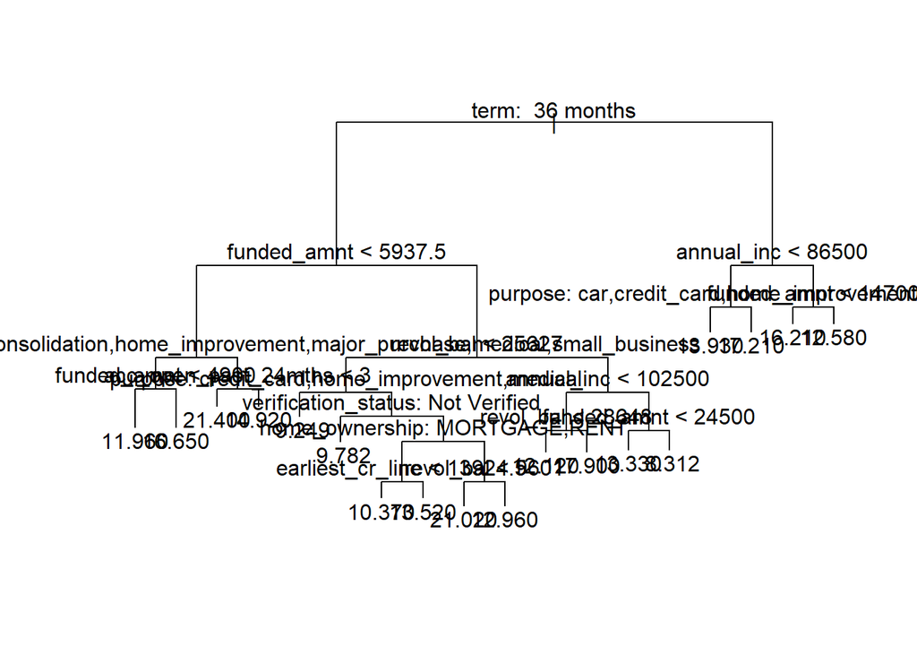

```r
treesm = tree(int_rate~., data = loans_trainsm)
plot(treesm)
text(treesm, pretty=0)
```

```r
preds = predict(treesm, newdata = loans_testsm)
mean((loans_testsm$int_rate - preds)^2)
```

```
## [1] 25.41935
```

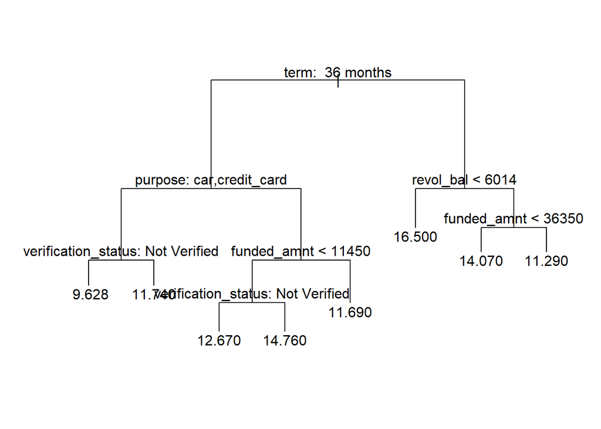

```r
treemed = tree(int_rate~., data = loans_trainmed)
plot(treemed)
text(treemed, pretty=0)
```

```r
preds = predict(treemed, newdata = loans_testmed)
mean((loans_testmed$int_rate - preds)^2)
```

```
## [1] 20.99743
```

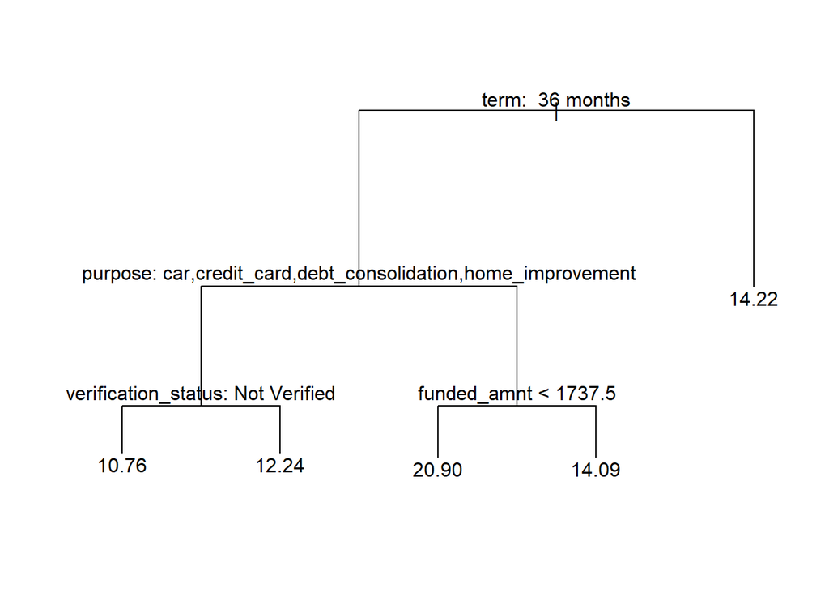

```r
treelar = tree(int_rate~., data = loans_trainlar)
plot(treelar)
text(treelar, pretty=0)
```